# Introduction to Neuroscience

Michelle R. Greene

Winter 2023

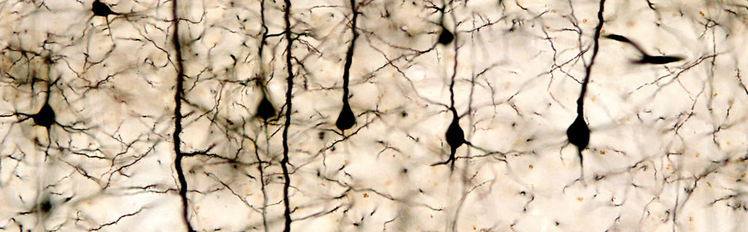

Instructor: Michelle R. Greene, Ph.D  
Email: mgreene2@bates.edu  
Office: Hathorn 111  
Office hours: MW: 9:30am - 10:30am OR [Book me via calendar](https://mrgreene09.github.io/IntroNeuroscience/meeting.html) if this time does not work.

[Hours for ARC tutoring](http://www.bates.edu/academic-resource-commons/neuro-tutoring-hours/)

Logistics: 4 lectures a week M,W,Th,F 11:00-11:55 in Hathorn 303

Prerequisites: A desire to work hard and learn!

# Course Description

In this course, we will explore how the structure and function of the central and peripheral nervous systems support mind and behavior. Topics introduced include neuroanatomy, developmental neurobiology, neurophysiology, neuropharmacology, and neuropsychiatry. The course is aimed at prospective majors and nonmajors interested in exploring a field in which biology and psychology merge, and to which many other disciplines (e.g., chemistry, philosophy, anthropology, linguistics, computer science) have contributed.

# Introduction

Your brain: it has the consistency of toothpaste, weighs about the same as a half gallon of milk, and would be the size of a large pizza if the outside (the cortex) were unwrinkled and flattened out on the table. On the one hand, the brain is just like any other organ in your body - it has ions, amino acids, and peptides that are shuttled around in little fatty globule cases packed with saltwater. But unlike any of your other organs, your brain creates your reality. Everything that makes you YOU: your memories, personality, perceptions, emotions, and talents are all due to this fantastic organ.

The overarching goal of this course is to give you the necessary background to appreciate how you are an “electrochemical meat computer”. To do this, we’ll be looking at the structure and function of the brain itself. We’ll delve into its structure and organization, its microscopic complexity, how it encodes, represents, and reacts to the physical world, and how its cells, systems, and molecules work together to produce states as intangible as hunger, sexual desire, and emotion.

There are more than 1,000 disorders of the brain and nervous system, and they result in more hospitalizations and lost productivity than any other disease group, including heart disease and cancer. In 2007, the World Health Organization estimated that up to one billion people are affected by neurological disorders worldwide, and this is not even including mental health issues or addiction! Here in the United States, neurological illness affects more than 50 million people annually, with another 44 million affected by mental disorders. The economic and emotional costs of these disorders is staggering.

No single concept in this course is overwhelmingly difficult, and I truly believe that with the right attitude, and enough time, effort, and patience, all of you will master the concepts in this course. That said, the sheer amount of information can feel overwhelming. But really, why shouldn’t it? Think about the task we’re up against! Trying to understand the brain is a quest only for the intrepid, the eager, and the truly curious.

# Learning Objectives

By the end of the course, you will be able to:

- Locate, name, and describe the basic functions of major brain regions and systems.
- Explain the basics of how neurons fire and communicate with other neurons, including: resting potentials, action potentials, sensory transduction, and receptive field structure.
- Describe how neurons and synapses are modified with experience, and how neural activity correlates with aspects of perception and behavior.
- Apply neuroscience principles to explain features of basic human behavior including eating, drinking, sleeping, sex, aggression, language, and learning.
- Describe what is known about the neural basis of various neurological diseases including: schizophrenia, depression, and addiction, and to identify environmental contexts that have an impact on brain health and function.
- Be able to critically evaluate neuroscience evidence that is presented in the popular media.

# Reading

We will be using several open textbooks for this course. Here are the links and abbreviations:  
ONI ([Open Neuroscience Initiative](https://www.austinlim.com/open-neuroscience-initiative)). [Link to book PDF](https://drive.google.com/file/d/1n08qgzhG5-RgkoqL_Aa4y1UBSycUcy5g/view).  
FN: [Foundations of Neuroscience](https://openbooks.lib.msu.edu/neuroscience/)  
NO: [Neuroscience Online](https://nba.uth.tmc.edu/neuroscience/m/index.htm)

# How to Succeed in this Course

## Reach out when you need support

- I am here for you and want you to succeed. Please reach out via email or schedule an office hours appointment.
- The [Academic Resource Commons (ARC)](https://www.bates.edu/academic-resource-commons/) is available to provide peer support in writing and content. The Academic Resource Commons (ARC) is Bates’ Learning & Writing Center. ARC is a place to do the work of being a student. Join us to study, write papers, and do your homework, surrounded by other students working on the same thing and by tutors: your fellow Bates students who have been through the courses that you’re taking now and have insight to share on how to excel in them. ARC offers in-person and online tutoring for writing, the sciences, languages, note-taking, time management, study habits, and much more. For more information, tutoring hours for all subjects, and upcoming workshops, visit us at https://www.bates.edu/arc. To make an appointment with a tutor, or for any question on our services, please stop by the ARC front desk (located on the first floor of Ladd Library) or click on the “Chat with ARC” button on our website homepage.
- [Counseling and Psychological Services (CAPS)](https://www.bates.edu/counseling-psychological-services/). Available to all Bates students, CAPS provides comprehensive, confidential mental health care. Services provided include assessment and evaluation, counseling, and referrals to off-campus providers for specialized or intensive treatment. Students can schedule an appointment by calling or visiting the office.
- [Health Services](https://www.bates.edu/health-services/). Operating in conjunction with Central Maine Medical Center (CMMC), Health Services is a place where students requiring care but not hospitalization may be seen for medical concerns. Services provided include general medical care, onsite pharmacy services, and diagnostic testing. Students can schedule an appointment by calling or visiting the office (31 Campus Ave), which is open Monday through Friday from 9am to 5pm.
- The [Multifaith Chaplaincy](https://www.bates.edu/multifaith/) warmly and creatively serves the religious, spiritual, searching, and seeking community at Bates. In addition to weekly and annual offerings, students can access confidential pastoral care and conversation by scheduling an appointment with a Multifaith Chaplain.
- The [Office of Intercultural Education](https://www.bates.edu/oie/) is a multipurpose space that welcomes those who value or embody diversity and aspire to participate in an inclusive community. Students come to the OIE to seek support from professional staff and build community among those with similar identities and experiences. Cultural affinity groups often gather and provide peer to peer programming and community. In addition, Bobcat First! serves as a resource for students who identify as first generation to college.
- [SPARQ!](https://www.bates.edu/oie/sparq/) is a multidimensional program dedicated to providing resources and support for the LGBTQIA+ community and their allies, including peer mentors, LGBTQIA+ community dinners, and educational opportunities. SPARQ! Peer Mentors provide one-on-one support for students who identify as LGBTQIA+ or are navigating their sexual, romantic, or gender identity. Students can be paired with a mentor for continuous support or drop-in during office hours.
- [Student Support Advisors (SSA)](https://www.bates.edu/student-affairs/student-support-and-advising/) provide personal support and supplemental academic advising to a cohort of students, responding to concerns as they arise. These advisors are the primary contact for personal and social concerns and a connection point for faculty who have concerns about a student, academic or otherwise. SSAs are listed in BatesReach under each student’s Success Network.
- The [IT Service Desk](https://bates.teamdynamix.com/TDClient/75/Portal/Home/?from=/helpdesk/) is the central location for all technology-related questions. If you are looking for an answer to a problem, check out their knowledge base. Here you will find answers to common questions or you can request assistance.

## Office Hours

Office hours are scheduled time outside of class to meet with students. Office hours are a time when you can meet with me to discuss the class materials or other related interests. This could include asking for extra help, seeking clarification of something presented in class, or following up on an aspect of the class that you find compelling. You should also feel free to discuss majoring in neuroscience (if you are considering it), summer research opportunities, graduate school, campus events, and much more.

You are encouraged, but not required, to attend office hours. I find that it’s very helpful to get to know you individually in office hours in a relatively large class like this one. I might ask you to come to office hours if I’d like to offer some support. Please know that this is not a punishment like detention in high school. Office hours do not have a lesson plan. I will assume that you will “drive” these meetings with your own questions and thoughts. A good way to prepare for office hours is to review your notes from class and the readings and to write down your questions ahead of time.

## Collaboration

Collaboration is the basis of all scientific discovery and is instrumental in the learning process. I strongly encourage students to form study groups and to review material together if possible.

# Policies

## Students with Disabilities or Learning Differences

If you think you need accommodation for a disability or learning difference, please let me know as soon as possible. Some aspects of this course may be modified to facilitate your participation and progress. You will need to create documentation with the [Office of the Dean of Students](http://www.bates.edu/accessible-education/). I will treat any information about your disability with the utmost discretion.

## Commitment to Equity and Diversity

Everyone has the right to be treated with dignity and respect in our classroom, and I am committed to making that happen. But this not only means your instructor treating you with respect, but also you treating *each other* that way. Disrespect or discrimination on any basis will not be tolerated. Whether inside or outside the classroom, if you encounter sexual harassment, sexual violence, or discrimination based on race, color, religion, age, national origin, ancestry, sex, sexual orientation, gender identity/expression, or disability, you are encouraged to report it to Gwen Lexow, Director of Title IX and Civil Rights Compliance at Bates at glexow@bates.edu or 207-786-6445. Additionally, please remember that Bates faculty are concerned about your well-being and development, and we are available to discuss any concerns you have. Students should be aware that faculty are legally obligated to share disclosures of sexual violence, sexual harassment, relationship violence, and stalking with the college’s Title IX Officer to help ensure that your safety and welfare are being addressed.

## Academic Integrity

Cheating is bad, I think we can all agree to that. The less acknowledged truth is that it’s not even worth it. Cheating cheapens the value of your work and everyone else’s, and a single violation can literally ruin your entire academic and professional career. Please remind yourself of the [Bates College policy on academic integrity](http://www.bates.edu/student-affairs/student-conduct/academic-integrity-policy/) and its definitions of plagiarism, use/misuse of sources, and cheating. Students’ work will be closely scrutinized for plagiarism and violations of the College policy will not be tolerated. If you are concerned that your collaboration might put you at risk of an academic integrity violation, please come see me during office hours as soon as possible. In my experience, violations of academic integrity are acts of desperation. If you are ever feeling desperate enough that a few extra points in this course seem to be worth risking so much, *please* consider talking to someone first — that could be me, a friend, or even someone at CAPS. I want you to succeed, and am happy to talk to you if you are feeling undue pressure from this course or anything else.

## Electronics

In our classroom, we are mindful of how we use technology, both for our own learning, and for those around us. Although we’ll be using our cell phones to respond to polls, we will place them face down or in a backpack or pocket when not in use. You may use a tablet or laptop for taking notes, but I strongly encourage you to avoid having your laptop out for other reasons: laptop use is [correlated with lower learning outcomes for you and those around you](http://www.sciencedirect.com/science/article/pii/S0360131506001436), and the act of [taking notes on the laptop is less effective than hand-written notes](http://pss.sagepub.com/content/25/6/1159.full).

## Late work

- Weekly quizzes generally *cannot* be made up. Please contact me ASAP if you have a known conflict (sports, debate, etc.) and as soon as possible if you are dealing with a personal or medical emergency.
- Perusall readings cannot be made up.
- If your problem set(s), research reflection, or ‘show and tell’ reflection is late, you will lose 10 percentage points per late day on that assignment. In other words, an assignment that would otherwise earn 100% would be worth 90% on the first late day, and 80% on the second late day. This policy does not apply to a documented personal or family emergency.

## Extra credit

I will not entertain requests or proposals for extra credit assignments.

## Emergencies

If I must cancel class due to weather or an emergency, I will inform you via the class email list. Please consider your Bates email to be the default place to look for class-related information and get into the habit of checking it daily.

## Because we are not yet out of the pandemic…

The ongoing Covid-19 pandemic necessitates flexibility from everyone for this course to take place in a safe and supportive environment. Below are some key considerations:

- To ensure the safety of other students and in line with Bates College and CDC health policies, everyone must wear a mask in the classroom at all times. Please ensure that your mask covers both your nose and mouth.
- Some students may need to attend class remotely on a temporary basis due to 1) testing positive for Covid-19, 2) being in close contact with someone who tested positive for Covid-19, or 3) experiencing symptoms of Covid-19 or are otherwise not feeling well. I encourage you to err on the side of caution and attend remotely. If you need to attend class remotely, please watch the live class session after it is posted on Lyceum and email me to schedule an office hours appointment to address any questions you may have about class content.
- As your instructor, I am working to ensure your safety by being fully vaccinated and boosted. However, if I test positive for Covid-19, have symptoms of Covid-19, or need to quarantine after spending time with someone who tests positive for Covid-19, the class will temporarily be moved to remote format via Zoom.
- I recognize that this may all seem very unfair. It is. You did not ask for a global crisis, and you may personally have been doing everything possible to do your part. You may be experiencing stress in other ways, such as if someone close to you becomes ill. If you find yourself struggling, please come talk to me. I will help support you and point you towards additional resources.

# Grading

## Grading philosophy

No single assignment listed below is worth more than 10% of your final grade. This is intentional. This allows anyone to bounce back from a less-than-optimal score on any assignment. If you approach this course with consistent effort, you will succeed!

## Assessed Components

**Weekly quizzes: 5% of semester grade each = 50% of semester total**  
Quizzes are 20 questions each and will open on Lyceum each Thursday at noon. They are due each Friday at 8 pm. Feedback and answer keys will be released after each quiz closes. The quizzes are all multiple choice, fill-in-the-blank, and matching. Each student will receive a random assortment of 20 questions from a larger quiz bank. On the Thursday class section, I will release to you a set of questions (but not possible answers) to quiz questions and we will have a guided study time.

**Perusall reading: 10% of semester grade, or about 0.4% per day**  
There will be a reading posted for each class period on Perusall. You can find our class Perusall link at the top of our Lyceum page. Perusall is a social reading annotation tool. In the PDF, you may highlight passages and figures for comment or question, follow up on the comments and questions or your colleagues, and use “upvoting” to endorse questions and comments. It’s a really great way of getting more out of your reading. As the annotations will in part guide the class activities, *you are expected to complete your annotations by midnight Eastern before each class session*.  
**Important note**: Perusall will assign you a “grade”, but it will not be used in this class. The primary reason for this is that their algorithm is a trade secret and I do not feel comfortable evaluating you with an algorithm that I may or may not agree with. Instead, your annotations will be graded on the following 0-1 scale: 0: does not meet expectations; 1: meets expectations. Please feel free to reach out if you have any questions about what constitutes a complete annotation.

**Participation: 5% of semester grade, or about 0.2% per day**  
We will be using MentiMeter for polling during class. At the end of each class, I will ask for a quick reflection that includes your main take-aways from the class and any questions you might have. I will use this as attendance and class participation.

**Problem sets: 10% of semester grade, or 5% each**  
Two problem sets are graded pass/fail and are intended to give you a snapshot of your neuroscience-related knowledge before and after the course. These are on a Google Form and are linked on Lyceum. The first problem set will be due **January 13, 2023 at 23:59**. The second problem set will be due **April 13, 2023 at 23:59**.

**Show and tell: 20% of semester grade (15% log and 5% reflection paper)**  
The purpose of this component is for you to engage with neuroscience in the news and popular culture, to allow you to make links between class content and neuroscience news, and to hone your critical thinking about the presentation of neuroscience in the media. Each week, I will expect you to come to class ready to speak about a piece of neuroscience in the popular media (including newspaper, magazine, blog, podcast, etc., but not including works of fiction). Some weeks, I will assign you a particular theme that relates to life in Maine (for example, the opioid crisis, lead poisoning, PFAS, etc.) In your small group discussion, you will discuss how the piece links to topics that we have covered in class as well as critique: what does this text tell us about the place of science in society? What hopes or ideals for us as individuals with brains does this piece represent? Your grade for this component will be a weekly log of your pieces (link to the piece and your main takeaway from your group discussion), and a 500-word reflective essay on all of your ‘show and tell’ pieces that will be due **April 21, 2023 at 12:30pm**.

**Research participation: 5% of semester grade**  
Participation in research is a valuable way to get first-hand exposure to the variety of research conducted within the Psychology and Neuroscience programs. There will be a number of student and faculty research projects recruiting participants this semester. You are expected to be involved in the equivalent of 2 units worth of participation or do an alternative writing assignment. You only get credit for participating in approved experiments. All eligible experiments are assigned a number and listed [on this webpage](https://www.bates.edu/psychology/participate-in-research/student-participation/).

Each experiment has a fixed number of units assigned to it based on the average length of time that it will take to participate. Typically, 1 hour worth of participation is equal to 1 unit, with each quarter hour represented by 0.25 units. Be sure to check the number of units when you sign up for the experiment. When you sign up for an experiment, you are making an appointment for which you **must** show up. Upon completion of the experiment, you will receive an email receipt crediting you for your participation. **Save this receipt!** Although it is the experimenter’s responsibility to report your participation to the department, this receipt is additional proof of your participation. You may need it to resolve discrepancies if they arise (and there are always several at the end of the semester). Please note that, for online studies in which your participation is entirely Internet-based, you will be prompted to provide your name and my name upon completion of the online study. This information will be recorded separately from your responses (to maintain the confidentiality of your data). **If you decide to opt for a writing assignment in lieu of research participation, you must notify me of this decision by 2/15/23 so that you receive instruction on the writing assignment in a timely manner**.

**Please sign up for experiments early – very few thesis students are still collecting data in mid-to-late March!**

Your final grade will be determined on the following scale:

[output not shown]

# Course Calendar

## Unit 1: Macro anatomy and physiology

| Date | Topic | Reading |
| --- | --- | --- |
| 01-11 | Introduction and history | Syllabus, [Optional: Finger](https://drive.google.com/file/d/1SInlbed2wDXHP5gTGENiQE3EONJLPlwa/view?usp=sharing) |
| 01-12 | Show and Tell #1 | **S&T log due** |
| 01-13 | Anatomy of the nervous system | [ONI Chapter 2](https://drive.google.com/file/d/1PQBN7sikA-axVHdgN0LnfErmxvWbPcWH/view?usp=sharing) |
|  |  | **Problem Set 1 due** |

## Unit 2: Micro anatomy and physiology

| Date | Topic | Reading |
| --- | --- | --- |
| 01-16 | **MLK DAY: NO CLASS** |  |
| 01-18 | Neurons and glia | [ONI Chapter 3](https://drive.google.com/file/d/1PRvmzM2lptCm81aEYW3EB37ZexOXxs_H/view?usp=sharing) |
| 01-19 | Show and Tell # 2: Find a news article that cites a scholarly source | **S&T log due** |
| 01-20 | Resting Potential | [ONI 4.1-4.3](https://drive.google.com/file/d/1PTr7Ek_PUOL-BKQOGy7sFoFY7ut9PDL1/view?usp=sharing) |
|  |  | **Quiz 1 due** |

| Date | Topic | Reading |
| --- | --- | --- |
| 01-23 | Resting Potential | [NO Chapter 1](https://nba.uth.tmc.edu/neuroscience/m/s1/chapter01.html) |
| 01-25 | Action Potential | [ONI 4.4](https://drive.google.com/file/d/1PUMP8b3C46wpnTgpe1Lx2OVTakNA8qyS/view?usp=sharing) |
| 01-26 | Show and Tell # 3: Find a news article that makes quantitative claims | **S&T log due** |
| 01-27 | Action Potential | [NO Chapter 2](https://nba.uth.tmc.edu/neuroscience/m/s1/chapter02.html); [ONI 4.5](https://drive.google.com/file/d/1PW95eN4OyFMn9NT_gU0B_admInotpPhv/view?usp=sharing) |
|  |  | **Quiz 2 due** |

| Date | Topic | Reading |
| --- | --- | --- |
| 01-30 | Synaptic Transmission | [ONI 5.1-5.3](https://drive.google.com/file/d/1PdYFvSXH0L4B78vkSc8m3FxpjgVFtc14/view?usp=sharing) |
| 02-01 | Synaptic Transmission | [NO Chapter 5](https://nba.uth.tmc.edu/neuroscience/m/s1/chapter05.html) |
| 02-02 | Show and Tell # 4: Find a news article about lead poisoning | **S&T log due** |
| 02-03 | Neurotransmitters | [ONI Chapter 5.4](https://drive.google.com/file/d/1RPmCfMkz5DQOuvb8MPrm4pSmYQ8mIHC9/view?usp=sharing) |
|  |  | **Quiz 3 due** |

## Unit 3: Inputs and Outputs (Sensory and Motor Systems)

| Date | Topic | Reading |
| --- | --- | --- |
| 02-06 | Auditory system | [ONI 8.1 and 8.2](https://drive.google.com/file/d/1RQEbxWWw3FSN-FKHAqyZh0WrHdxFfUTJ/view?usp=sharing) |
| 02-08 | Visual system | [ONI 7.1-7.3](https://drive.google.com/file/d/1RRvtA6GJytyqmd7h8gJ0miqTdPVlRZlZ/view?usp=sharing) |
| 02-09 | Show and Tell #5: Find an article of your choice | **S&T log due** |
| 02-10 | Visual system | [ONI 7.4](https://drive.google.com/file/d/1RVXUlYm2tysOTLegW-pwawXS3Hln0ijj/view?usp=sharing) |
|  |  | **Quiz 4 due** |

| Date | Topic | Reading |
| --- | --- | --- |
| 02-13 | Olfaction and taste | [ONI 9.1-9.2](https://drive.google.com/file/d/1RVv89Z9ufLkV2RJYhgV304W0azo6qMwf/view?usp=sharing) |
| 02-15 | Somatic senses | [ONI 8.3](https://drive.google.com/file/d/1RWEM955-mgsbc_CkJxdAHc0Usxes8iV5/view?usp=sharing) |
| 02-16 | Show and Tell #6: Find an article that relates to a sensory system | **S&T log due** |
| 02-17 | Motor systems | [ONI 10.3-10.4](https://drive.google.com/file/d/1RZv67B8RK-4Ii5vJilFjByh8SbnlKOI8/view?usp=sharing) |
|  |  | **Quiz 5 due** |

| Date | Topic | Reading |
| --- | --- | --- |
| 02-20 | WINTER RECESS |  |
| 02-22 | WINTER RECESS |  |
| 02-23 | WINTER RECESS |  |
| 02-24 | WINTER RECESS |  |
| 02-27 | Motor systems | [ONI 10.1-10.2](https://drive.google.com/file/d/1RZq6GTQljmg8-5kLMyMwfXQqxAAJuErm/view?usp=sharing) |

## Unit 4: Behavioral Neuroscience

[output not shown]

| Date | Topic | Reading |
| --- | --- | --- |
| 03-06 | Sleep | [Selection from Freberg *Discovering Behavioral Neuroscience*](https://drive.google.com/file/d/1RyPmpABIP8Dwk1IZfOoobpYvCbCsDfNI/view?usp=sharing) |
| 03-08 | Sleep | [Selection from Freberg *Discovering Behavioral Neuroscience*](https://drive.google.com/file/d/1S-_PwPHWNZXoh9Cq97VY03PGjyFZGAQs/view?usp=sharing) |
| 03-09 | Show and Tell #8: Find an article that relates to sleep | **S&T log due** |
| 03-10 | Sex, gender, sexual orientation, and reproduction | [Selection from Freberg *Discovering Behavioral Neuroscience* pages 1-26 required, 27-37 optional](https://drive.google.com/file/d/1S0ZNh437WUAYuX9PQ5glislOgfhL_kAW/view?usp=sharing) |
|  |  | **Quiz 7 due** |

| Date | Topic | Reading |
| --- | --- | --- |
| 03-13 | Drugs and addiction | [ONI 11.1-11.3](https://drive.google.com/file/d/1S1KqVKZ11sm8Av42C8z0CkRKV2Vw7jTS/view?usp=sharing) |
| 03-15 | Emotion | [ONI Chapter 15](https://drive.google.com/file/d/1S47OjrTv1cfiNY-jREWcZI9BMRbcEgFx/view?usp=sharing) |
| 03-16 | Show and Tell #9: Find an article about the opioid crisis | **S&T log due** |

## Unit 5: Learning and Memory

| Date | Topic | Reading |
| --- | --- | --- |
| 03-17 | Attention | [Selection from Bear *Neuroscience: Exploring the Brain*](https://drive.google.com/file/d/1S5Q4qXcGnF6Z2aoaKm8y1a8h_Ueksy0Q/view?usp=sharing) |
|  |  | **Quiz 8 due** |

| Date | Topic | Reading |
| --- | --- | --- |
| 03-20 | Attention | [Selection from Bear *Neuroscience: Exploring the Brain*](https://drive.google.com/file/d/1S7edtuAA8FSkVygPF5iJeXR44VeDR3xZ/view?usp=sharing) |
| 03-22 | WINTER RECESS |  |
| 03-23 | WINTER RECESS |  |
| 03-24 | WINTER RECESS |  |

| Date | Topic | Reading |
| --- | --- | --- |
| 03-27 | Memory | [ONI 13.1-13.2](https://drive.google.com/file/d/1S9lF8nhJOF-qpEAJ2omqckjI12RiZAsX/view?usp=sharing) |
| 03-29 | Memory | [ONI 13.3-13.5](https://drive.google.com/file/d/1SALBcTIQaTS9nxQ65e85hQNF2ROzY4ri/view?usp=sharing) |
| 03-30 | Show and Tell #10: Find an article about Covid-19 and cognition | **S&T log due** |
| 03-31 | Learning and plasticity | [NO Chapter 7](https://nba.uth.tmc.edu/neuroscience/m/s4/chapter07.html) |
|  |  | **Quiz 9 due** |

| Date | Topic | Reading |
| --- | --- | --- |
| 04-03 | Language | [ONI 14.2](https://drive.google.com/file/d/1SVZfudCCTwFV8BGA5gvoVp0rKleKO9Yh/view?usp=sharing) |
| 04-05 | Consciousness | [Scholarpedia: Neural Correlates of Consciousness](http://www.scholarpedia.org/article/Neural_correlates_of_consciousness) |
| 04-06 | Show and Tell #11: Find an article of your choice | **S&T log due** |
| 04-07 | Consciousness | [Owen (2016) Decoding thoughts in disorders of consciousness](https://drive.google.com/file/d/1SaRL_Etm_zBzYMLkOegHvZUMyXfahaDJ/view?usp=sharing) |
|  |  | **Quiz 10 due** |

## Unit 6: Order and Disorder

| Date | Topic | Reading |
| --- | --- | --- |
| 04-10 | Brain disorders | [ONI Chapter 16](https://drive.google.com/file/d/1ScPb7E3ATvBrMejfSOjXCmTCccP5Ky4H/view?usp=sharing) |
| 04-12 | Brain disorders | [Selections on disorders](https://drive.google.com/file/d/1Sd-QVHwcDu-vTbl7YBeK0lrPXidRyu9i/view?usp=sharing) |
| 04-13 | Show and Tell # 12: Find an article about head injuries in the NFL | **Problem Set 2 Due** |
| 04-14 | Mythbusting Neuroscience |  |